# Tugas Kuliah Pertemuan 3

# Library

```r
library(dLagM)
library(dynlm)
library(MLmetrics)
library(lmtest)
library(car)
```

# SOAL 1 : Pangsa Pasar (Y) terhadap Harga (X)

Data pangsa pasar (*market share*) dan harga (*price*) suatu produk pasta gigi selama 20 periode.

## Data

```r
Period <- 1:20
MarketShare <- c(3.63, 4.20, 3.33, 4.54, 2.89, 4.87, 4.90, 5.29, 6.18, 7.20,
                 7.25, 6.09, 6.80, 8.65, 8.43, 8.29, 7.18, 7.90, 8.45, 8.23)
Price <- c(0.97, 0.95, 0.99, 0.91, 0.98, 0.90, 0.89, 0.86, 0.85, 0.82,
           0.79, 0.83, 0.81, 0.77, 0.76, 0.80, 0.83, 0.79, 0.76, 0.78)

data1 <- data.frame(t = Period, Yt = MarketShare, Xt = Price)
str(data1)
```

```
## 'data.frame':    20 obs. of  3 variables:
##  $ t : int  1 2 3 4 5 6 7 8 9 10 ...
##  $ Yt: num  3.63 4.2 3.33 4.54 2.89 4.87 4.9 5.29 6.18 7.2 ...
##  $ Xt: num  0.97 0.95 0.99 0.91 0.98 0.9 0.89 0.86 0.85 0.82 ...
```

```r
data1
```

```
##     t   Yt   Xt
## 1   1 3.63 0.97
## 2   2 4.20 0.95
## 3   3 3.33 0.99
## 4   4 4.54 0.91
## 5   5 2.89 0.98
## 6   6 4.87 0.90
## 7   7 4.90 0.89
## 8   8 5.29 0.86
## 9   9 6.18 0.85
## 10 10 7.20 0.82
## 11 11 7.25 0.79
## 12 12 6.09 0.83
## 13 13 6.80 0.81
## 14 14 8.65 0.77
## 15 15 8.43 0.76
## 16 16 8.29 0.80
## 17 17 7.18 0.83
## 18 18 7.90 0.79
## 19 19 8.45 0.76
## 20 20 8.23 0.78
```

## Eksplorasi Data

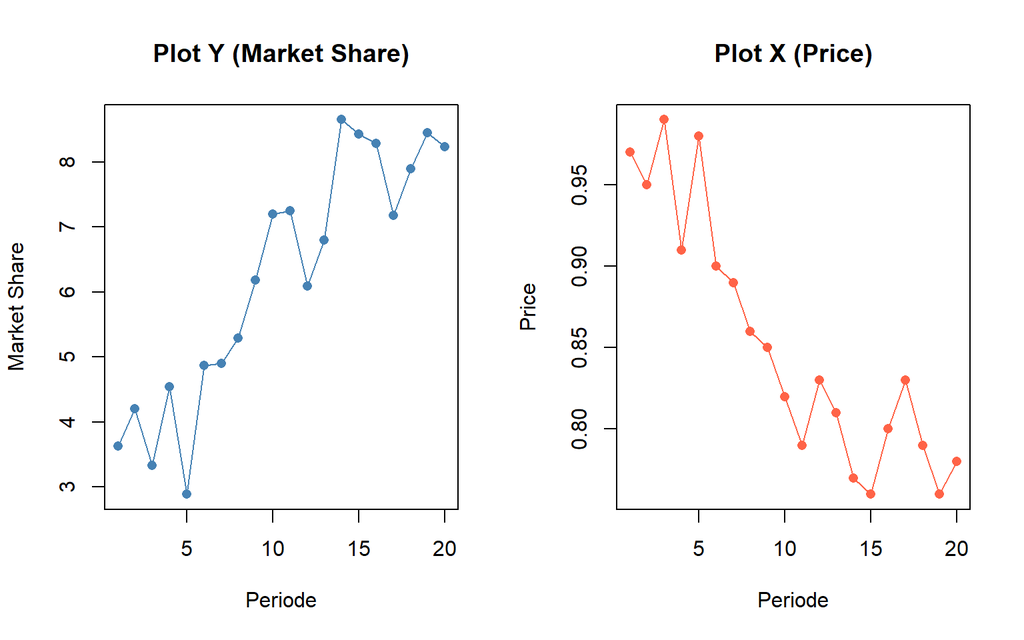

```r
par(mfrow = c(1, 2))
plot(data1$t, data1$Yt, type = "o", pch = 16, col = "steelblue",
     xlab = "Periode", ylab = "Market Share", main = "Plot Y (Market Share)")
plot(data1$t, data1$Xt, type = "o", pch = 16, col = "tomato",
     xlab = "Periode", ylab = "Price", main = "Plot X (Price)")
```

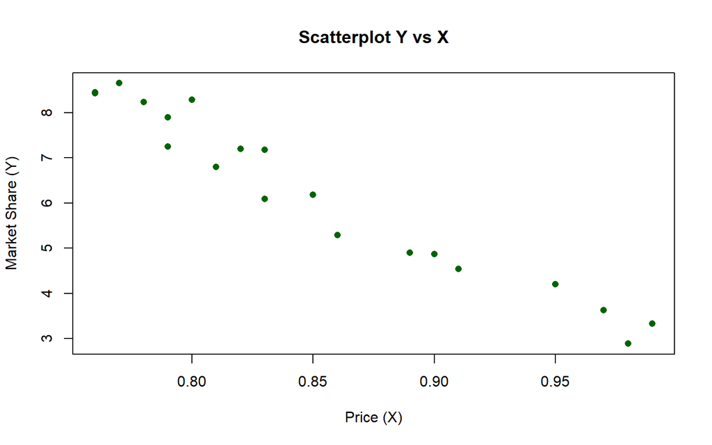

```r
par(mfrow = c(1, 1))

plot(data1$Xt, data1$Yt, pch = 16, col = "darkgreen",
     xlab = "Price (X)", ylab = "Market Share (Y)",
     main = "Scatterplot Y vs X")
```

```r
cor(data1$Yt, data1$Xt)
```

```
## [1] -0.9752564
```

Korelasi sebesar $-0,9753$ menunjukkan hubungan negatif yang sangat kuat antara harga dan pangsa pasar. Oleh karena itu, hubungan tersebut layak dilanjutkan ke pemodelan *distributed lag* untuk mengetahui apakah pengaruh harga terhadap pangsa pasar bersifat langsung melalui $X_t$ atau tertunda pada beberapa periode, yaitu $X_{t-1}, X_{t-2}, \dots$.

## Pembagian Data (80% train : 20% test)

```r
train1 <- data1[1:16, ]
test1  <- data1[17:20, ]

train1.ts <- ts(train1)
test1.ts  <- ts(test1)
data1.ts  <- ts(data1)
```

## Model 1: Koyck

```r
model1.koyck <- koyckDlm(x = train1$Xt, y = train1$Yt)
summary(model1.koyck)
```

```
##
## Call:
## "Y ~ (Intercept) + Y.1 + X.t"
##
## Residuals:
##      Min       1Q   Median       3Q      Max
## -1.08831 -0.33583  0.03809  0.32369  1.08271
##
## Coefficients:
##             Estimate Std. Error t value Pr(>|t|)
## (Intercept)  14.1547    13.9055   1.018    0.329
## Y.1           0.4356     0.4547   0.958    0.357
## X.t         -12.4022    13.2392  -0.937    0.367
##
## Residual standard error: 0.6214 on 12 degrees of freedom
## Multiple R-Squared: 0.9013,  Adjusted R-squared: 0.8848
## Wald test: 42.97 on 2 and 12 DF,  p-value: 3.383e-06
##
## Diagnostic tests:
## NULL
##
##                             alpha      beta       phi
## Geometric coefficients:  25.08051 -12.40215 0.4356312
```

```r
AIC(model1.koyck)
```

```
## [1] 32.94998
```

```r
BIC(model1.koyck)
```

```
## [1] 35.78218
```

Peubah $Y_{t-1}$ memiliki nilai-p sebesar 0,357 dan peubah $X_t$ memiliki nilai-p sebesar 0,367. Karena kedua nilai-p $> 0,05$, maka kedua peubah tersebut tidak berpengaruh signifikan secara parsial terhadap $Y_t$. Namun, hasil Wald test menunjukkan nilai-p sebesar $3,383 \times 10^{-6} < 0,05$, sehingga model secara keseluruhan signifikan.

Model yang terbentuk adalah:

$$\hat{Y}_t = 14,1547 - 12,4022X_t + 0,4356Y_{t-1}$$

Nilai $R^2 = 0,9013$ menunjukkan bahwa sebesar 90,13% variasi $Y_t$ dapat dijelaskan oleh model.

### Peramalan dan Akurasi

```r
fore1.koyck <- forecast(model = model1.koyck, x = test1$Xt, h = nrow(test1))
fore1.koyck
```

```
## $forecasts
## [1] 7.472253 7.612103 8.045091 7.985671
##
## $call
## forecast.koyckDlm(model = model1.koyck, x = test1$Xt, h = nrow(test1))
##
## attr(,"class")
## [1] "forecast.koyckDlm" "dLagM"
```

```r
mape1.koyck <- MAPE(fore1.koyck$forecasts, test1$Yt)
mape1.koyck          # akurasi data test
```

```
## [1] 0.03868805
```

```r
GoF(model1.koyck)    # akurasi data train
```

```
##               n       MAE         MPE       MAPE      sMAPE      MASE       MSE
## model1.koyck 15 0.4501447 -0.01928604 0.08947964 0.08570486 0.5178329 0.3089595
##                  MRAE     GMRAE
## model1.koyck 1.706297 0.6506363
```

Model Koyck menghasilkan ramalan sebesar 7,4723; 7,6121; 8,0451; dan 7,9857. Berdasarkan evaluasi, diperoleh MAE sebesar 0,4501, MSE sebesar 0,3090, dan MAPE sebesar 0,0895, yang menunjukkan bahwa model memiliki kesalahan peramalan yang relatif rendah.

## Model 2: Distributed Lag Model (q = 2)

```r
model1.dlm <- dlm(x = train1$Xt, y = train1$Yt, q = 2)
summary(model1.dlm)
```

```
##
## Call:
## lm(formula = model.formula, data = design)
##
## Residuals:
##      Min       1Q   Median       3Q      Max
## -0.74815 -0.25820  0.02732  0.28252  0.63650
##
## Coefficients:
##             Estimate Std. Error t value Pr(>|t|)
## (Intercept)   27.690      1.699  16.293 1.58e-08 ***
## x.t          -20.911      4.094  -5.107 0.000459 ***
## x.1           -1.384      3.484  -0.397 0.699626
## x.2           -2.930      4.279  -0.685 0.509026
## ---
## Signif. codes:  0 '***' 0.001 '**' 0.01 '*' 0.05 '.' 0.1 ' ' 1
##
## Residual standard error: 0.4876 on 10 degrees of freedom
## Multiple R-squared:  0.9456, Adjusted R-squared:  0.9293
## F-statistic: 57.99 on 3 and 10 DF,  p-value: 1.255e-06
##
## AIC and BIC values for the model:
##        AIC      BIC
## 1 24.90966 28.10495
```

```r
AIC(model1.dlm)
```

```
## [1] 24.90966
```

```r
BIC(model1.dlm)
```

```
## [1] 28.10495
```

Berdasarkan hasil estimasi, peubah $X_t$ memiliki nilai-p sebesar 0,000459 < 0,05 sehingga berpengaruh signifikan terhadap $Y_t$. Sementara itu, peubah $X_{t-1}$ dan $X_{t-2}$ memiliki nilai-p masing-masing sebesar 0,699626 dan 0,509026 > 0,05 sehingga tidak berpengaruh signifikan terhadap $Y_t$.

Model secara keseluruhan signifikan berdasarkan uji F dengan nilai-p sebesar $1,255 \times 10^{-6} < 0,05$. Nilai $R^2$ sebesar 0,9456 menunjukkan bahwa 94,56% variasi $Y_t$ dapat dijelaskan oleh $X_t$, $X_{t-1}$, dan $X_{t-2}$.

Model yang terbentuk adalah:

$$\hat{Y}_t = 27,690 - 20,911X_t - 1,384X_{t-1} - 2,930X_{t-2}$$

Berdasarkan nilai AIC sebesar 24,9097 dan BIC sebesar 28,1050, model dapat digunakan untuk pemodelan *distributed lag* dengan lag hingga 2 periode.

### Peramalan dan Akurasi

```r
fore1.dlm <- forecast(model = model1.dlm, x = test1$Xt, h = nrow(test1))
fore1.dlm
```

```
## $forecasts
## [1] 7.000140 7.677840 8.272596 8.013110
##
## $call
## forecast.dlm(model = model1.dlm, x = test1$Xt, h = nrow(test1))
##
## attr(,"class")
## [1] "forecast.dlm" "dLagM"
```

```r
mape1.dlm <- MAPE(fore1.dlm$forecasts, test1$Yt)
mape1.dlm
```

```
## [1] 0.02512994
```

```r
GoF(model1.dlm)
```

```
##             n       MAE          MPE       MAPE      sMAPE      MASE       MSE
## model1.dlm 14 0.3271441 -0.001862647 0.05567658 0.05583942 0.3763605 0.1698395
##                MRAE     GMRAE
## model1.dlm 1.266737 0.3698695
```

Hasil peramalan model *distributed lag* menghasilkan nilai ramalan sebesar 7,0001; 7,6778; 8,2726; dan 8,0131 untuk empat periode ke depan. Berdasarkan hasil evaluasi, diperoleh MAE sebesar 0,3271, MSE sebesar 0,1698, dan MAPE sebesar 0,0557. Nilai MAPE yang rendah menunjukkan bahwa model memiliki tingkat kesalahan peramalan yang relatif kecil.

## Model 3: Distributed Lag Model dengan Lag Optimum

```r
finiteDLMauto(formula = Yt ~ Xt,
              data = data.frame(train1),
              q.min = 1, q.max = 6,
              model.type = "dlm", error.type = "AIC", trace = TRUE)
```

```
##   q - k    MASE      AIC      BIC   GMRAE    MBRAE R.Adj.Sq  Ljung-Box
## 6     6 0.13287  1.98713  4.71040 0.18229 -1.24656  0.96533 0.01068512
## 3     3 0.34462 22.56595 25.95564 0.52942 -0.28497  0.92805 0.36111348
## 4     4 0.40523 24.69501 28.08935 0.62345 -0.23409  0.90356 0.39796261
## 2     2 0.37636 24.90966 28.10495 0.36987  0.48249  0.92933 0.60057711
## 1     1 0.41045 25.13707 27.96927 0.40480  0.34718  0.93158 0.34041201
## 5     5 0.45914 25.46443 28.64759 0.51799 -0.39806  0.80070 0.75246966
```

Berdasarkan hasil perbandingan model, model dengan lag 6 memiliki performa terbaik karena menghasilkan nilai MASE paling kecil, yaitu 0,13287, serta nilai AIC sebesar 1,98713 dan BIC sebesar 4,71040 yang paling rendah dibandingkan model lainnya. Selain itu, model lag 6 memiliki nilai $R^2$ terkoreksi sebesar 0,96533 yang menunjukkan kemampuan model dalam menjelaskan variasi $Y_t$ sebesar 96,53%. Oleh karena itu, model dengan lag 6 dipilih sebagai model *distributed lag* terbaik.

```r
qauto <- finiteDLMauto(formula = Yt ~ Xt, data = data.frame(train1),
                       q.min = 1, q.max = 6,
                       model.type = "dlm", error.type = "AIC", trace = FALSE)
q.opt <- as.numeric(rownames(qauto)[which.min(qauto$AIC)])
q.opt
```

```
## [1] 6
```

```r
model1.dlm2 <- dlm(x = train1$Xt, y = train1$Yt, q = q.opt)
summary(model1.dlm2)
```

```
##
## Call:
## lm(formula = model.formula, data = design)
##
## Residuals:
##        1        2        3        4        5        6        7        8
## -0.03176  0.09878 -0.04964 -0.06891  0.09801 -0.01274 -0.11718  0.14837
##        9       10
## -0.19442  0.12948
##
## Coefficients:
##               Estimate Std. Error t value Pr(>|t|)
## (Intercept)  39.610423   2.445120  16.200  0.00379 **
## x.t         -44.999765   5.805344  -7.751  0.01624 *
## x.1          -0.003881   4.972069  -0.001  0.99945
## x.2          -0.754941   3.126247  -0.241  0.83168
## x.3           2.613010   3.441267   0.759  0.52695
## x.4          20.866178   4.944108   4.220  0.05182 .
## x.5          -0.225961   3.105220  -0.073  0.94861
## x.6         -17.222920   3.651689  -4.716  0.04213 *
## ---
## Signif. codes:  0 '***' 0.001 '**' 0.01 '*' 0.05 '.' 0.1 ' ' 1
##
## Residual standard error: 0.243 on 2 degrees of freedom
## Multiple R-squared:  0.9923, Adjusted R-squared:  0.9653
## F-statistic:  36.8 on 7 and 2 DF,  p-value: 0.02671
##
## AIC and BIC values for the model:
##        AIC    BIC
## 1 1.987134 4.7104
```

```r
AIC(model1.dlm2)
```

```
## [1] 1.987134
```

```r
BIC(model1.dlm2)
```

```
## [1] 4.7104
```

Berdasarkan hasil estimasi, peubah $X_t$ memiliki nilai-p sebesar 0,01624 < 0,05 sehingga berpengaruh signifikan terhadap $Y_t$. Peubah $X_{t-6}$ juga berpengaruh signifikan dengan nilai-p sebesar 0,04213 < 0,05. Sementara itu, peubah $X_{t-1}$, $X_{t-2}$, $X_{t-3}$, dan $X_{t-5}$ tidak berpengaruh signifikan karena memiliki nilai-p > 0,05. Peubah $X_{t-4}$ memiliki nilai-p sebesar 0,05182 sehingga tidak signifikan pada taraf 5%, tetapi mendekati signifikan.

Model secara keseluruhan signifikan berdasarkan uji F dengan nilai-p sebesar 0,02671 < 0,05. Nilai $R^2$ sebesar 0,9923 menunjukkan bahwa 99,23% variasi $Y_t$ dapat dijelaskan oleh peubah dalam model, sedangkan 0,77% dijelaskan oleh faktor lain di luar model.

Model yang terbentuk adalah:

$$\hat{Y}_t = 39,6104 - 44,9998X_t - 0,0039X_{t-1} - 0,7549X_{t-2} +
2,6130X_{t-3} + 20,8662X_{t-4} - 0,2260X_{t-5} - 17,2229X_{t-6}$$

Model ini memiliki nilai AIC sebesar 1,9871 dan BIC sebesar 4,7104.

### Peramalan dan Akurasi

```r
fore1.dlm2 <- forecast(model = model1.dlm2, x = test1$Xt, h = nrow(test1))
mape1.dlm2 <- MAPE(fore1.dlm2$forecasts, test1$Yt)
mape1.dlm2
```

```
## [1] 0.07898388
```

```r
GoF(model1.dlm2)
```

```
##              n        MAE           MPE       MAPE      sMAPE      MASE
## model1.dlm2 10 0.09492917 -0.0001507547 0.01314349 0.01314632 0.1328713
##                    MSE      MRAE     GMRAE
## model1.dlm2 0.01180581 0.4890752 0.1822903
```

Hasil peramalan model distributed lag dengan lag 6 menghasilkan nilai MAPE sebesar 0,07898. Berdasarkan hasil evaluasi, diperoleh MAE sebesar 0,09493, MAPE sebesar 0,01314, dan MASE sebesar 0,13287. Nilai MAPE yang sangat kecil menunjukkan bahwa model memiliki tingkat kesalahan peramalan yang rendah sehingga model distributed lag dengan lag 6 memiliki kemampuan peramalan yang baik.

## Model 4: Autoregressive (ARDL p = 1, q = 1)

```r
model1.ardl <- ardlDlm(formula = Yt ~ Xt, data = train1, p = 1, q = 1)
summary(model1.ardl)
```

```
##
## Time series regression with "ts" data:
## Start = 2, End = 16
##
## Call:
## dynlm(formula = as.formula(model.text), data = data)
##
## Residuals:
##     Min      1Q  Median      3Q     Max
## -0.5826 -0.2578 -0.1355  0.2923  0.6791
##
## Coefficients:
##             Estimate Std. Error t value Pr(>|t|)
## (Intercept)  16.0526     8.5567   1.876   0.0874 .
## Xt.t        -22.3164     3.0888  -7.225  1.7e-05 ***
## Xt.1          7.6883     8.0695   0.953   0.3612
## Yt.1          0.4233     0.3292   1.286   0.2249
## ---
## Signif. codes:  0 '***' 0.001 '**' 0.01 '*' 0.05 '.' 0.1 ' ' 1
##
## Residual standard error: 0.4664 on 11 degrees of freedom
## Multiple R-squared:  0.949,  Adjusted R-squared:  0.9351
## F-statistic: 68.25 on 3 and 11 DF,  p-value: 2.147e-07
```

```r
AIC(model1.ardl)
```

```
## [1] 25.03625
```

```r
BIC(model1.ardl)
```

```
## [1] 28.57651
```

Berdasarkan hasil estimasi model ARDL(1,1), peubah $X_t$ memiliki nilai-p sebesar $1,7 \times 10^{-5} < 0,05$ sehingga berpengaruh signifikan terhadap $Y_t$. Sementara itu, $X_{t-1}$ dan $Y_{t-1}$ memiliki nilai-p masing-masing sebesar 0,3612 dan 0,2249 $> 0,05$, sehingga keduanya tidak berpengaruh signifikan terhadap $Y_t$.

Model secara keseluruhan signifikan berdasarkan uji F dengan nilai-p sebesar $2,147 \times 10^{-7} < 0,05$. Nilai $R^2$ sebesar 0,9490 menunjukkan bahwa 94,90% variasi $Y_t$ dapat dijelaskan oleh model ARDL(1,1).

Model yang terbentuk adalah:

$$\hat{Y}_t = 16,0526 - 22,3164X_t + 7,6883X_{t-1} + 0,4233Y_{t-1}$$

Model memiliki nilai AIC sebesar 25,0363 dan BIC sebesar 28,5765.

### Peramalan dan Akurasi

```r
fore1.ardl <- forecast(model = model1.ardl, x = test1$Xt, h = nrow(test1))
fore1.ardl
```

```
## $forecasts
## [1] 7.189733 7.847306 8.487607 8.081662
##
## $call
## forecast.ardlDlm(model = model1.ardl, x = test1$Xt, h = nrow(test1))
##
## attr(,"class")
## [1] "forecast.ardlDlm" "dLagM"
```

```r
mape1.ardl <- MAPE(fore1.ardl$forecasts, test1$Yt)
mape1.ardl
```

```
## [1] 0.007625056
```

```r
GoF(model1.ardl)
```

```
##              n       MAE          MPE       MAPE      sMAPE      MASE       MSE
## model1.ardl 15 0.3576038 -0.003051323 0.06189325 0.06186574 0.4113766 0.1595401
##                 MRAE     GMRAE
## model1.ardl 2.079258 0.6117331
```

## Lag Optimum Model Autoregressive

```r
model1.ardl.opt <- ardlBoundOrders(data = data.frame(data1), ic = "AIC",
                                   formula = Yt ~ Xt)
model1.ardl.opt$Stat.table
```

```
##           q = 1     q = 2     q = 3     q = 4     q = 5     q = 6 q = 7 q = 8
## p = 1 26.443222 25.585928  27.90404  28.15440  15.86472  12.16060    NA    NA
## p = 2 25.284828 27.280557  29.39566  28.28302 -12.95797 -20.41095    NA    NA
## p = 3 29.665001 29.665001  29.54627  29.21222 -11.13376        NA    NA    NA
## p = 4 28.638892 29.730704  29.73070  25.21244 -34.02031        NA    NA    NA
## p = 5  9.600496 -1.718359 -18.02940 -18.02940        NA        NA    NA    NA
## p = 6 17.113404        NA        NA        NA        NA        NA    NA    NA
##       q = 9 q = 10 q = 11 q = 12 q = 13 q = 14 q = 15
## p = 1    NA     NA     NA     NA     NA     NA     NA
## p = 2    NA     NA     NA     NA     NA     NA     NA
## p = 3    NA     NA     NA     NA     NA     NA     NA
## p = 4    NA     NA     NA     NA     NA     NA     NA
## p = 5    NA     NA     NA     NA     NA     NA     NA
## p = 6    NA     NA     NA     NA     NA     NA     NA
```

```r
min_p <- c()
for (i in 1:6) {
  min_p[i] <- min(model1.ardl.opt$Stat.table[[i]], na.rm = TRUE)
}
q_opt <- which(min_p == min(min_p, na.rm = TRUE))
p_opt <- which(model1.ardl.opt$Stat.table[[q_opt]] ==
                 min(model1.ardl.opt$Stat.table[[q_opt]], na.rm = TRUE))
data.frame("q_optimum" = q_opt, "p_optimum" = p_opt,
           "AIC" = model1.ardl.opt$min.Stat)
```

```
##   q_optimum p_optimum       AIC
## 1         5         4 -34.02031
```

## Pemodelan dengan `dynlm`

```r
cons_lm1 <- dynlm(Yt ~ Xt + L(Xt), data = train1.ts)
cons_lm2 <- dynlm(Yt ~ Xt + L(Yt), data = train1.ts)
cons_lm3 <- dynlm(Yt ~ Xt + L(Xt) + L(Yt), data = train1.ts)
cons_lm4 <- dynlm(Yt ~ Xt + L(Xt) + L(Xt, 2), data = train1.ts)

summary(cons_lm1)
```

```
##
## Time series regression with "ts" data:
## Start = 2, End = 16
##
## Call:
## dynlm(formula = Yt ~ Xt + L(Xt), data = train1.ts)
##
## Residuals:
##      Min       1Q   Median       3Q      Max
## -0.68398 -0.32960 -0.00941  0.38401  0.78629
##
## Coefficients:
##             Estimate Std. Error t value Pr(>|t|)
## (Intercept)   26.885      1.545  17.400 7.04e-10 ***
## Xt           -22.363      3.172  -7.051 1.34e-05 ***
## L(Xt)         -1.962      3.047  -0.644    0.532
## ---
## Signif. codes:  0 '***' 0.001 '**' 0.01 '*' 0.05 '.' 0.1 ' ' 1
##
## Residual standard error: 0.479 on 12 degrees of freedom
## Multiple R-squared:  0.9414, Adjusted R-squared:  0.9316
## F-statistic: 96.31 on 2 and 12 DF,  p-value: 4.069e-08
```

```r
summary(cons_lm2)
```

```
##
## Time series regression with "ts" data:
## Start = 2, End = 16
##
## Call:
## dynlm(formula = Yt ~ Xt + L(Yt), data = train1.ts)
##
## Residuals:
##      Min       1Q   Median       3Q      Max
## -0.70994 -0.31840 -0.02846  0.34447  0.69144
##
## Coefficients:
##             Estimate Std. Error t value Pr(>|t|)
## (Intercept)  23.6430     3.1104   7.601 6.32e-06 ***
## Xt          -21.4428     2.9382  -7.298 9.50e-06 ***
## L(Yt)         0.1316     0.1206   1.092    0.296
## ---
## Signif. codes:  0 '***' 0.001 '**' 0.01 '*' 0.05 '.' 0.1 ' ' 1
##
## Residual standard error: 0.4646 on 12 degrees of freedom
## Multiple R-squared:  0.9448, Adjusted R-squared:  0.9356
## F-statistic: 102.7 on 2 and 12 DF,  p-value: 2.826e-08
```

```r
summary(cons_lm3)
```

```
##
## Time series regression with "ts" data:
## Start = 2, End = 16
##
## Call:
## dynlm(formula = Yt ~ Xt + L(Xt) + L(Yt), data = train1.ts)
##
## Residuals:
##     Min      1Q  Median      3Q     Max
## -0.5826 -0.2578 -0.1355  0.2923  0.6791
##
## Coefficients:
##             Estimate Std. Error t value Pr(>|t|)
## (Intercept)  16.0526     8.5567   1.876   0.0874 .
## Xt          -22.3164     3.0888  -7.225  1.7e-05 ***
## L(Xt)         7.6883     8.0695   0.953   0.3612
## L(Yt)         0.4233     0.3292   1.286   0.2249
## ---
## Signif. codes:  0 '***' 0.001 '**' 0.01 '*' 0.05 '.' 0.1 ' ' 1
##
## Residual standard error: 0.4664 on 11 degrees of freedom
## Multiple R-squared:  0.949,  Adjusted R-squared:  0.9351
## F-statistic: 68.25 on 3 and 11 DF,  p-value: 2.147e-07
```

```r
summary(cons_lm4)
```

```
##
## Time series regression with "ts" data:
## Start = 3, End = 16
##
## Call:
## dynlm(formula = Yt ~ Xt + L(Xt) + L(Xt, 2), data = train1.ts)
##
## Residuals:
##      Min       1Q   Median       3Q      Max
## -0.74815 -0.25820  0.02732  0.28252  0.63650
##
## Coefficients:
##             Estimate Std. Error t value Pr(>|t|)
## (Intercept)   27.690      1.699  16.293 1.58e-08 ***
## Xt           -20.911      4.094  -5.107 0.000459 ***
## L(Xt)         -1.384      3.484  -0.397 0.699626
## L(Xt, 2)      -2.930      4.279  -0.685 0.509026
## ---
## Signif. codes:  0 '***' 0.001 '**' 0.01 '*' 0.05 '.' 0.1 ' ' 1
##
## Residual standard error: 0.4876 on 10 degrees of freedom
## Multiple R-squared:  0.9456, Adjusted R-squared:  0.9293
## F-statistic: 57.99 on 3 and 10 DF,  p-value: 1.255e-06
```

Berdasarkan hasil estimasi model, pada model $Y_t \sim X_t + X_{t-1}$, peubah $X_t$ berpengaruh signifikan terhadap $Y_t$ dengan nilai-p sebesar $1,34 \times 10^{-5} < 0,05$, sedangkan $X_{t-1}$ tidak signifikan dengan nilai-p sebesar $0,532 > 0,05$. Model memiliki nilai $R^2$ sebesar $0,9414$, yang menunjukkan bahwa $94,14%$ variasi $Y_t$ dapat dijelaskan oleh model. Uji F menunjukkan model secara keseluruhan signifikan dengan nilai-p sebesar $4,069 \times 10^{-8}$. Model yang terbentuk adalah

$$\hat{Y}_t = 26,885 - 22,363X_t - 1,962X_{t-1}.$$

Pada model $Y_t \sim X_t + Y_{t-1}$, peubah $X_t$ berpengaruh signifikan terhadap $Y_t$ dengan nilai-p sebesar $9,50 \times 10^{-6} < 0,05$, sedangkan $Y_{t-1}$ tidak signifikan dengan nilai-p sebesar $0,296 > 0,05$. Model memiliki nilai $R^2$ sebesar $0,9448$, sehingga $94,48%$ variasi $Y_t$ dapat dijelaskan oleh model. Uji F menunjukkan model secara keseluruhan signifikan dengan nilai-p sebesar $2,826 \times 10^{-8}$. Model yang terbentuk adalah

$$\hat{Y}_t = 23,6430 - 21,4428X_t + 0,1316Y_{t-1}.$$

Pada model ARDL(1,1), peubah $X_t$ berpengaruh signifikan terhadap $Y_t$ dengan nilai-p sebesar $1,7 \times 10^{-5} < 0,05$, sedangkan $X_{t-1}$ dan $Y_{t-1}$ tidak signifikan dengan nilai-p masing-masing sebesar $0,3612$ dan $0,2249 > 0,05$. Model memiliki nilai $R^2$ sebesar $0,9490$, sehingga $94,90%$ variasi $Y_t$ dapat dijelaskan oleh model. Uji F menunjukkan model secara keseluruhan signifikan dengan nilai-p sebesar $2,147 \times 10^{-7}$. Model yang terbentuk adalah

$$\hat{Y}_t = 16,0526 - 22,3164X_t + 7,6883X_{t-1} + 0,4233Y_{t-1}.$$

Pada model distributed lag dengan lag hingga $2$, peubah $X_t$ berpengaruh signifikan terhadap $Y_t$ dengan nilai-p sebesar $0,000459 < 0,05$, sedangkan $X_{t-1}$ dan $X_{t-2}$ tidak signifikan dengan nilai-p masing-masing sebesar $0,699626$ dan $0,509026 > 0,05$. Model memiliki nilai $R^2$ sebesar $0,9456$, sehingga $94,56%$ variasi $Y_t$ dapat dijelaskan oleh model. Uji F menunjukkan model secara keseluruhan signifikan dengan nilai-p sebesar $1,255 \times 10^{-6}$. Model yang terbentuk adalah

$$\hat{Y}_t = 27,690 - 20,911X_t - 1,384X_{t-1} - 2,930X_{t-2}.$$

### SSE

```r
data.frame(
  Model = c("cons_lm1", "cons_lm2", "cons_lm3", "cons_lm4"),
  SSE = c(deviance(cons_lm1), deviance(cons_lm2),
          deviance(cons_lm3), deviance(cons_lm4))
)
```

```
##      Model      SSE
## 1 cons_lm1 2.752871
## 2 cons_lm2 2.590590
## 3 cons_lm3 2.393101
## 4 cons_lm4 2.377753
```

Berdasarkan nilai SSE, **cons_lm4** memiliki nilai SSE paling kecil, yaitu sebesar $2,377753$, dibandingkan model lainnya. Selanjutnya, cons_lm3 memiliki SSE sebesar $2,393101$, cons_lm2 sebesar $2,590590$, dan cons_lm1 sebesar $2,752871$. Karena nilai SSE yang lebih kecil menunjukkan tingkat kesalahan yang lebih rendah, maka **cons_lm4 merupakan model terbaik berdasarkan kriteria SSE**.

### Uji Encompassing

```r
encomptest(cons_lm1, cons_lm2)
```

```
## Encompassing test
##
## Model 1: Yt ~ Xt + L(Xt)
## Model 2: Yt ~ Xt + L(Yt)
## Model E: Yt ~ Xt + L(Xt) + L(Yt)
##           Res.Df Df      F Pr(>F)
## M1 vs. ME     11 -1 1.6537 0.2249
## M2 vs. ME     11 -1 0.9078 0.3612
```

Berdasarkan hasil *encompassing test*, diperoleh nilai-p sebesar $0,2249$ untuk perbandingan M1 dengan ME dan sebesar $0,3612$ untuk perbandingan M2 dengan ME. Kedua nilai-p tersebut lebih besar dari taraf nyata $0,05$, sehingga tidak terdapat bukti yang cukup untuk menolak hipotesis nol pada kedua pengujian.

Dengan demikian, **M1 dan M2 tidak dapat dinyatakan mengandung informasi yang lebih unggul satu sama lain melalui model encompassing (ME)**. Oleh karena itu, berdasarkan *encompassing test*, tidak terdapat bukti yang cukup untuk memilih salah satu model secara signifikan dibandingkan model lainnya.

### Uji Autokorelasi (Durbin-Watson)

```r
dwtest(cons_lm1)
```

```
##
##  Durbin-Watson test
##
## data:  cons_lm1
## DW = 1.2509, p-value = 0.04163
## alternative hypothesis: true autocorrelation is greater than 0
```

```r
dwtest(cons_lm2)
```

```
##
##  Durbin-Watson test
##
## data:  cons_lm2
## DW = 1.485, p-value = 0.08951
## alternative hypothesis: true autocorrelation is greater than 0
```

```r
dwtest(cons_lm3)
```

```
##
##  Durbin-Watson test
##
## data:  cons_lm3
## DW = 1.8314, p-value = 0.272
## alternative hypothesis: true autocorrelation is greater than 0
```

```r
dwtest(cons_lm4)
```

```
##
##  Durbin-Watson test
##
## data:  cons_lm4
## DW = 1.4728, p-value = 0.1279
## alternative hypothesis: true autocorrelation is greater than 0
```

Berdasarkan uji Durbin-Watson, pada **cons_lm1** diperoleh nilai DW sebesar $1,2509$ dengan nilai-p sebesar $0,04163 < 0,05$. Hal ini menunjukkan adanya **autokorelasi positif** pada residual model cons_lm1.

Pada **cons_lm2**, diperoleh nilai DW sebesar $1,485$ dengan nilai-p sebesar $0,08951 > 0,05$, sehingga tidak terdapat bukti yang cukup adanya autokorelasi positif pada residual.

Pada **cons_lm3**, diperoleh nilai DW sebesar $1,8314$ dengan nilai-p sebesar $0,272 > 0,05$, sehingga tidak terdapat bukti adanya autokorelasi positif pada residual.

Pada **cons_lm4**, diperoleh nilai DW sebesar $1,4728$ dengan nilai-p sebesar $0,1279 > 0,05$, sehingga tidak terdapat bukti yang cukup adanya autokorelasi positif pada residual.

Dengan demikian, **cons_lm1 mengalami masalah autokorelasi positif**, sedangkan **cons_lm2, cons_lm3, dan cons_lm4 tidak menunjukkan adanya autokorelasi positif yang signifikan** berdasarkan uji Durbin-Watson.

### Uji Heteroskedastisitas (Breusch-Pagan)

```r
bptest(cons_lm1)
```

```
##
##  studentized Breusch-Pagan test
##
## data:  cons_lm1
## BP = 4.4251, df = 2, p-value = 0.1094
```

```r
bptest(cons_lm2)
```

```
##
##  studentized Breusch-Pagan test
##
## data:  cons_lm2
## BP = 3.4803, df = 2, p-value = 0.1755
```

```r
bptest(cons_lm3)
```

```
##
##  studentized Breusch-Pagan test
##
## data:  cons_lm3
## BP = 5.0799, df = 3, p-value = 0.166
```

```r
bptest(cons_lm4)
```

```
##
##  studentized Breusch-Pagan test
##
## data:  cons_lm4
## BP = 6.4848, df = 3, p-value = 0.09026
```

Berdasarkan uji *Breusch-Pagan*, diperoleh nilai-p sebesar $0,1094$ pada cons_lm1, $0,1755$ pada cons_lm2, $0,1660$ pada cons_lm3, dan $0,09026$ pada cons_lm4. Seluruh nilai-p lebih besar dari taraf nyata $0,05$, sehingga tidak terdapat bukti yang cukup untuk menolak hipotesis nol.

Dengan demikian, **cons_lm1, cons_lm2, cons_lm3, dan cons_lm4 tidak mengalami masalah heteroskedastisitas**, atau dapat dikatakan bahwa residual pada keempat model memiliki ragam yang homogen (*homoskedastisitas*).

### Uji Normalitas Sisaan (Shapiro-Wilk)

$H_0$: sisaan berdistribusi normal; $H_1$: sisaan tidak berdistribusi normal.

```r
shapiro.test(residuals(cons_lm1))
```

```
##
##  Shapiro-Wilk normality test
##
## data:  residuals(cons_lm1)
## W = 0.95903, p-value = 0.6756
```

```r
shapiro.test(residuals(cons_lm2))
```

```
##
##  Shapiro-Wilk normality test
##
## data:  residuals(cons_lm2)
## W = 0.96691, p-value = 0.81
```

```r
shapiro.test(residuals(cons_lm3))
```

```
##
##  Shapiro-Wilk normality test
##
## data:  residuals(cons_lm3)
## W = 0.9301, p-value = 0.2738
```

```r
shapiro.test(residuals(cons_lm4))
```

```
##
##  Shapiro-Wilk normality test
##
## data:  residuals(cons_lm4)
## W = 0.95718, p-value = 0.6764
```

Berdasarkan uji Shapiro-Wilk, diperoleh nilai-p sebesar $0,6756$ pada cons_lm1, $0,8100$ pada cons_lm2, $0,2738$ pada cons_lm3, dan $0,6764$ pada cons_lm4. Seluruh nilai-p lebih besar dari taraf nyata $0,05$, sehingga tidak terdapat bukti yang cukup untuk menolak hipotesis nol.

Dengan demikian, **residual pada cons_lm1, cons_lm2, cons_lm3, dan cons_lm4 berdistribusi normal**. Artinya, keempat model telah memenuhi asumsi normalitas residual.

## Perbandingan Model

```r
akurasi1 <- matrix(c(mape1.koyck, mape1.dlm, mape1.dlm2, mape1.ardl))
row.names(akurasi1) <- c("Koyck", "DLM q=2", paste0("DLM q=", q.opt),
                         "Autoregressive")
colnames(akurasi1) <- c("MAPE")
akurasi1
```

```
##                       MAPE
## Koyck          0.038688050
## DLM q=2        0.025129937
## DLM q=6        0.078983884
## Autoregressive 0.007625056
```

```r
best1 <- row.names(akurasi1)[which.min(akurasi1[, 1])]
best1
```

```
## [1] "Autoregressive"
```

Berdasarkan hasil perbandingan nilai MAPE, model **Autoregressive** memiliki nilai MAPE paling kecil, yaitu sebesar $0,007625$ atau sekitar $0,76%$. Selanjutnya, model DLM $q=2$ memiliki MAPE sebesar $2,51%$, model Koyck sebesar $3,87%$, dan model DLM $q=6$ sebesar $7,90%$. Karena nilai MAPE yang lebih kecil menunjukkan tingkat kesalahan peramalan yang lebih rendah, maka **model Autoregressive dipilih sebagai model terbaik dalam melakukan peramalan**.

## Plot Perbandingan Peramalan

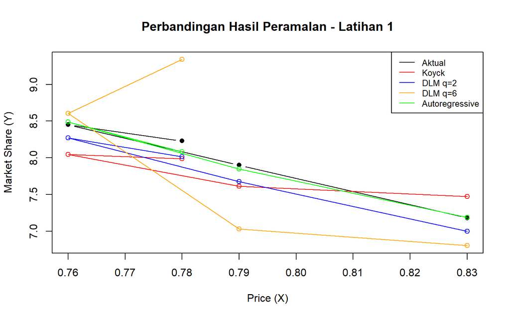

```r
plot(test1$Xt, test1$Yt, type = "b", col = "black", pch = 16,
     ylim = range(c(test1$Yt, fore1.koyck$forecasts, fore1.dlm$forecasts,
                    fore1.dlm2$forecasts, fore1.ardl$forecasts)),
     xlab = "Price (X)", ylab = "Market Share (Y)",
     main = "Perbandingan Hasil Peramalan - Latihan 1")
points(test1$Xt, fore1.koyck$forecasts, col = "red");    lines(test1$Xt, fore1.koyck$forecasts, col = "red")
points(test1$Xt, fore1.dlm$forecasts, col = "blue");     lines(test1$Xt, fore1.dlm$forecasts, col = "blue")
points(test1$Xt, fore1.dlm2$forecasts, col = "orange");  lines(test1$Xt, fore1.dlm2$forecasts, col = "orange")
points(test1$Xt, fore1.ardl$forecasts, col = "green");   lines(test1$Xt, fore1.ardl$forecasts, col = "green")
legend("topright",
       c("Aktual", "Koyck", "DLM q=2", paste0("DLM q=", q.opt), "Autoregressive"),
       lty = 1, col = c("black", "red", "blue", "orange", "green"), cex = 0.8)
```

## Kesimpulan

Hubungan antara harga dan pangsa pasar bersifat negatif dan kuat. Empat pendekatan telah dicobakan: Koyck, DLM dengan $q=2$, DLM dengan lag optimum (berdasarkan AIC), serta model *autoregressive* ARDL(1,1). Berdasarkan tabel perbandingan MAPE data uji, model terbaik adalah model dengan MAPE terkecil Autoregresive . Uji asumsi (Durbin-Watson, Breusch-Pagan, dan Shapiro-Wilk) digunakan untuk memastikan sisaan model terpilih tidak berautokorelasi, memiliki ragam homogen, serta berdistribusi normal.

# SOAL 2 : Sales (Y) terhadap Advertising (X)

Data penjualan (*sales*) dan belanja iklan (*advertising*) tahun 1975–2014.

## Data

```r
Year <- 1975:2014
Sales <- c(11.7, 12.0, 12.3, 12.8, 13.1, 13.6, 13.9, 14.4, 14.7, 15.3,
           15.5, 15.8, 16.1, 16.6, 16.9, 16.7, 16.9, 17.4, 17.6, 17.9,
           18.0, 17.9, 18.0, 18.2, 18.2, 18.3, 18.6, 19.2, 19.3, 19.5,
           19.2, 19.3, 19.5, 20.0, 20.0, 19.9, 19.8, 19.9, 20.2, 21.0)
Advertising <- c(9.4, 9.6, 10.0, 10.4, 10.8, 10.9, 11.7, 12.2, 12.5, 12.9,
                 13.0, 13.2, 13.8, 14.2, 14.6, 14.4, 15.0, 15.4, 15.7, 15.9,
                 15.9, 16.0, 16.3, 16.2, 16.8, 17.3, 17.6, 18.1, 18.3, 18.5,
                 18.7, 18.9, 19.2, 20.0, 20.0, 20.3, 20.4, 21.0, 21.5, 22.1)

data2 <- data.frame(Year = Year, Yt = Sales, Xt = Advertising)
str(data2)
```

```
## 'data.frame':    40 obs. of  3 variables:
##  $ Year: int  1975 1976 1977 1978 1979 1980 1981 1982 1983 1984 ...
##  $ Yt  : num  11.7 12 12.3 12.8 13.1 13.6 13.9 14.4 14.7 15.3 ...
##  $ Xt  : num  9.4 9.6 10 10.4 10.8 10.9 11.7 12.2 12.5 12.9 ...
```

```r
head(data2, 10)
```

```
##    Year   Yt   Xt
## 1  1975 11.7  9.4
## 2  1976 12.0  9.6
## 3  1977 12.3 10.0
## 4  1978 12.8 10.4
## 5  1979 13.1 10.8
## 6  1980 13.6 10.9
## 7  1981 13.9 11.7
## 8  1982 14.4 12.2
## 9  1983 14.7 12.5
## 10 1984 15.3 12.9
```

## Eksplorasi Data

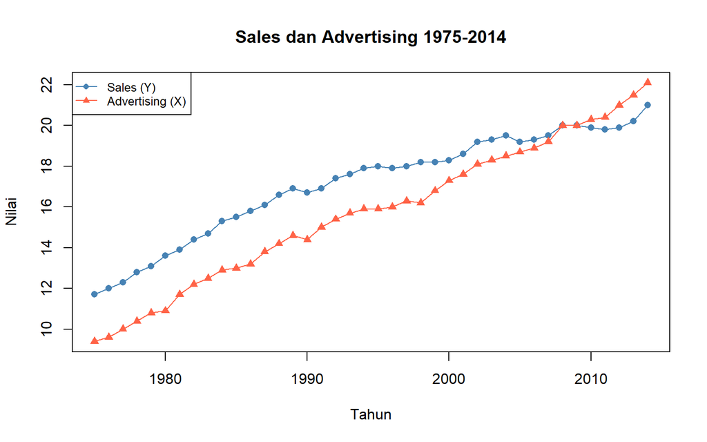

```r
plot(data2$Year, data2$Yt, type = "o", pch = 16, col = "steelblue",
     ylim = range(c(data2$Yt, data2$Xt)),
     xlab = "Tahun", ylab = "Nilai", main = "Sales dan Advertising 1975-2014")
lines(data2$Year, data2$Xt, type = "o", pch = 17, col = "tomato")
legend("topleft", c("Sales (Y)", "Advertising (X)"),
       lty = 1, pch = c(16, 17), col = c("steelblue", "tomato"), cex = 0.8)
```

```r
cor(data2$Yt, data2$Xt)
```

```
## [1] 0.9795849
```

## Pembagian Data (80% train : 20% test)

```r
train2 <- data2[1:32, ]   # 1975-2006
test2  <- data2[33:40, ]  # 2007-2014

train2.ts <- ts(train2)
test2.ts  <- ts(test2)
data2.ts  <- ts(data2)
```

## Model 1: Koyck

```r
model2.koyck <- koyckDlm(x = train2$Xt, y = train2$Yt)
summary(model2.koyck)
```

```
##
## Call:
## "Y ~ (Intercept) + Y.1 + X.t"
##
## Residuals:
##      Min       1Q   Median       3Q      Max
## -0.42880 -0.09790 -0.01132  0.09751  0.38616
##
## Coefficients:
##             Estimate Std. Error t value Pr(>|t|)
## (Intercept)  1.41668    0.43419   3.263   0.0029 **
## Y.1          0.84065    0.10190   8.250  5.6e-09 ***
## X.t          0.09730    0.08718   1.116   0.2739
## ---
## Signif. codes:  0 '***' 0.001 '**' 0.01 '*' 0.05 '.' 0.1 ' ' 1
##
## Residual standard error: 0.1818 on 28 degrees of freedom
## Multiple R-Squared: 0.9939,  Adjusted R-squared: 0.9935
## Wald test:  2292 on 2 and 28 DF,  p-value: < 2.2e-16
##
## Diagnostic tests:
## NULL
##
##                            alpha       beta       phi
## Geometric coefficients:  8.89017 0.09729997 0.8406466
```

```r
AIC(model2.koyck)
```

```
## [1] -12.89328
```

```r
BIC(model2.koyck)
```

```
## [1] -7.157335
```

```r
fore2.koyck <- forecast(model = model2.koyck, x = test2$Xt, h = nrow(test2))
fore2.koyck
```

```
## $forecasts
## [1] 19.50932 19.76312 19.97648 20.18503 20.37007 20.58401 20.81251 21.06297
##
## $call
## forecast.koyckDlm(model = model2.koyck, x = test2$Xt, h = nrow(test2))
##
## attr(,"class")
## [1] "forecast.koyckDlm" "dLagM"
```

```r
mape2.koyck <- MAPE(fore2.koyck$forecasts, test2$Yt)
mape2.koyck
```

```
## [1] 0.01553823
```

```r
GoF(model2.koyck)
```

```
##               n       MAE           MPE        MAPE      sMAPE      MASE
## model2.koyck 31 0.1342519 -0.0001867148 0.008178547 0.00817584 0.4738303
##                     MSE     MRAE    GMRAE
## model2.koyck 0.02984154 50362273 0.753862
```

Berdasarkan hasil estimasi model Koyck, peubah $Y_{t-1}$ berpengaruh signifikan terhadap $Y_t$ dengan nilai-p sebesar $5,6 \times 10^{-9} < 0,05$, sedangkan peubah $X_t$ tidak berpengaruh signifikan dengan nilai-p sebesar $0,2739 > 0,05$. Intersep juga signifikan dengan nilai-p sebesar $0,0029 < 0,05$.

Nilai $R^2$ sebesar $0,9939$ menunjukkan bahwa sebesar $99,39%$ variasi $Y_t$ dapat dijelaskan oleh model. Uji Wald menunjukkan bahwa model secara keseluruhan signifikan dengan nilai-p $< 2,2 \times 10^{-16}$.

Model Koyck yang terbentuk adalah

$$\hat{Y}_t = 1,41668 + 0,84065Y_{t-1} + 0,09730X_t.$$

Berdasarkan koefisien geometrik, diperoleh $\alpha=8,89017$, $\beta=0,09730$, dan $\phi=0,84065$. Nilai $\phi$ yang positif menunjukkan adanya pengaruh tertunda dari $X_t$ terhadap $Y_t$ yang berlangsung secara geometris dari waktu ke waktu.

Hasil peramalan untuk delapan periode ke depan adalah $19,50932$, $19,76312$, $19,97648$, $20,18503$, $20,37007$, $20,58401$, $20,81251$, dan $21,06297$. Nilai MAPE sebesar $0,01554$ atau sekitar $1,55%$ menunjukkan bahwa tingkat kesalahan peramalan relatif rendah. Selain itu, nilai MASE sebesar $0,4738 < 1$ menunjukkan bahwa model Koyck memiliki kinerja peramalan yang lebih baik dibandingkan metode *naive*. Dengan demikian, model Koyck memiliki kemampuan peramalan yang baik.

## Model 2: Distributed Lag Model (q = 2)

```r
model2.dlm <- dlm(x = train2$Xt, y = train2$Yt, q = 2)
summary(model2.dlm)
```

```
##
## Call:
## lm(formula = model.formula, data = design)
##
## Residuals:
##      Min       1Q   Median       3Q      Max
## -0.66716 -0.15331  0.05975  0.21779  0.49109
##
## Coefficients:
##             Estimate Std. Error t value Pr(>|t|)
## (Intercept)   5.3117     0.4096  12.968 7.37e-13 ***
## x.t           0.2014     0.2899   0.695    0.493
## x.1           0.4296     0.3728   1.152    0.260
## x.2           0.1523     0.2811   0.542    0.593
## ---
## Signif. codes:  0 '***' 0.001 '**' 0.01 '*' 0.05 '.' 0.1 ' ' 1
##
## Residual standard error: 0.3247 on 26 degrees of freedom
## Multiple R-squared:  0.9791, Adjusted R-squared:  0.9767
## F-statistic: 405.4 on 3 and 26 DF,  p-value: < 2.2e-16
##
## AIC and BIC values for the model:
##        AIC      BIC
## 1 23.36095 30.36694
```

```r
AIC(model2.dlm)
```

```
## [1] 23.36095
```

```r
BIC(model2.dlm)
```

```
## [1] 30.36694
```

```r
fore2.dlm <- forecast(model = model2.dlm, x = test2$Xt, h = nrow(test2))
mape2.dlm <- MAPE(fore2.dlm$forecasts, test2$Yt)
mape2.dlm
```

```
## [1] 0.05444612
```

```r
GoF(model2.dlm)
```

```
##             n      MAE           MPE       MAPE     sMAPE      MASE        MSE
## model2.dlm 30 0.250373 -0.0006085903 0.01536926 0.0153258 0.8854654 0.09139979
##                MRAE    GMRAE
## model2.dlm 22272733 1.596656
```

Berdasarkan hasil estimasi model DLM dengan lag hingga 2 periode, diperoleh bahwa $X_t$, $X_{t-1}$, dan $X_{t-2}$ tidak berpengaruh signifikan terhadap $Y_t$, karena masing-masing memiliki nilai-p sebesar $0,493$, $0,260$, dan $0,593 > 0,05$. Sementara itu, intersep berpengaruh signifikan dengan nilai-p sebesar $7,37 \times 10^{-13} < 0,05$.

Nilai $R^2$ sebesar $0,9791$ menunjukkan bahwa sebesar $97,91%$ variasi $Y_t$ dapat dijelaskan oleh model. Uji F menunjukkan bahwa model secara keseluruhan signifikan dengan nilai-p $< 2,2 \times 10^{-16}$.

Model yang terbentuk adalah

$$\hat{Y}_t = 5,3117 + 0,2014X_t + 0,4296X_{t-1} + 0,1523X_{t-2}.$$

## Model 3: DLM dengan Lag Optimum

```r
qauto2 <- finiteDLMauto(formula = Yt ~ Xt, data = data.frame(train2),
                        q.min = 1, q.max = 10,
                        model.type = "dlm", error.type = "AIC", trace = TRUE)
q.opt2 <- as.numeric(rownames(qauto2)[which.min(qauto2$AIC)])
q.opt2
```

```
## [1] 10
```

```r
model2.dlm2 <- dlm(x = train2$Xt, y = train2$Yt, q = q.opt2)
summary(model2.dlm2)
```

```
##
## Call:
## lm(formula = model.formula, data = design)
##
## Residuals:
##      Min       1Q   Median       3Q      Max
## -0.30778 -0.14687  0.02925  0.10616  0.31482
##
## Coefficients:
##             Estimate Std. Error t value Pr(>|t|)
## (Intercept)  9.08973    1.14057   7.969 1.22e-05 ***
## x.t          0.07740    0.26088   0.297    0.773
## x.1          0.42488    0.32343   1.314    0.218
## x.2         -0.03042    0.31532  -0.096    0.925
## x.3         -0.05505    0.30111  -0.183    0.859
## x.4         -0.24718    0.30104  -0.821    0.431
## x.5          0.24553    0.27020   0.909    0.385
## x.6         -0.14879    0.26932  -0.552    0.593
## x.7          0.13757    0.27576   0.499    0.629
## x.8         -0.09399    0.28623  -0.328    0.749
## x.9         -0.08646    0.32282  -0.268    0.794
## x.10         0.36644    0.27555   1.330    0.213
## ---
## Signif. codes:  0 '***' 0.001 '**' 0.01 '*' 0.05 '.' 0.1 ' ' 1
##
## Residual standard error: 0.2178 on 10 degrees of freedom
## Multiple R-squared:  0.9838, Adjusted R-squared:  0.9659
## F-statistic: 55.14 on 11 and 10 DF,  p-value: 1.905e-07
##
## AIC and BIC values for the model:
##        AIC      BIC
## 1 4.031384 18.21494
```

```r
fore2.dlm2 <- forecast(model = model2.dlm2, x = test2$Xt, h = nrow(test2))
mape2.dlm2 <- MAPE(fore2.dlm2$forecasts, test2$Yt)
mape2.dlm2
```

```
## [1] 0.02016401
```

```r
GoF(model2.dlm2)
```

```
##              n       MAE           MPE       MAPE       sMAPE      MASE
## model2.dlm2 22 0.1250566 -8.741402e-05 0.00708797 0.007082121 0.5252377
##                    MSE     MRAE    GMRAE
## model2.dlm2 0.02157003 70495450 1.196558
```

Berdasarkan hasil estimasi model DLM dengan lag hingga 10 periode, seluruh peubah $X_t$ hingga $X_{t-10}$ tidak berpengaruh signifikan terhadap $Y_t$, karena seluruh nilai-p lebih besar dari $0,05$. Sementara itu, intersep berpengaruh signifikan dengan nilai-p sebesar $1,22 \times 10^{-5} < 0,05$.

Nilai $R^2$ sebesar $0,9838$ menunjukkan bahwa sebesar $98,38%$ variasi $Y_t$ dapat dijelaskan oleh model. Uji F menunjukkan bahwa model secara keseluruhan signifikan dengan nilai-p sebesar $1,905 \times 10^{-7} < 0,05$.

Model yang terbentuk adalah

$$\begin{aligned}
\hat{Y}_t ={}& 9,08973 + 0,07740X_t + 0,42488X_{t-1} -
0,03042X_{t-2} - 0,05505X_{t-3}\\
&- 0,24718X_{t-4} + 0,24553X_{t-5} - 0,14879X_{t-6}\\
&+ 0,13757X_{t-7} - 0,09399X_{t-8} - 0,08646X_{t-9} +
0,36644X_{t-10}.
\end{aligned}$$

## Model 4: ARDL (p = 1, q = 1)

```r
model2.ardl <- ardlDlm(formula = Yt ~ Xt, data = train2, p = 1, q = 1)
summary(model2.ardl)
```

```
##
## Time series regression with "ts" data:
## Start = 2, End = 32
##
## Call:
## dynlm(formula = as.formula(model.text), data = data)
##
## Residuals:
##      Min       1Q   Median       3Q      Max
## -0.42212 -0.13934  0.00585  0.09313  0.33270
##
## Coefficients:
##             Estimate Std. Error t value Pr(>|t|)
## (Intercept)  1.30304    0.47500   2.743   0.0107 *
## Xt.t         0.30844    0.15564   1.982   0.0578 .
## Xt.1        -0.20644    0.17382  -1.188   0.2453
## Yt.1         0.83951    0.09995   8.399  5.2e-09 ***
## ---
## Signif. codes:  0 '***' 0.001 '**' 0.01 '*' 0.05 '.' 0.1 ' ' 1
##
## Residual standard error: 0.1791 on 27 degrees of freedom
## Multiple R-squared:  0.9943, Adjusted R-squared:  0.9937
## F-statistic:  1575 on 3 and 27 DF,  p-value: < 2.2e-16
```

```r
AIC(model2.ardl)
```

```
## [1] -12.93737
```

```r
BIC(model2.ardl)
```

```
## [1] -5.767436
```

```r
fore2.ardl <- forecast(model = model2.ardl, x = test2$Xt, h = nrow(test2))
fore2.ardl
```

```
## $forecasts
## [1] 19.52586 19.90030 20.04949 20.26727 20.41900 20.71081 20.98614 21.29912
##
## $call
## forecast.ardlDlm(model = model2.ardl, x = test2$Xt, h = nrow(test2))
##
## attr(,"class")
## [1] "forecast.ardlDlm" "dLagM"
```

```r
mape2.ardl <- MAPE(fore2.ardl$forecasts, test2$Yt)
mape2.ardl
```

```
## [1] 0.01905123
```

```r
GoF(model2.ardl)
```

```
##              n       MAE          MPE        MAPE       sMAPE      MASE
## model2.ardl 31 0.1351188 -0.000172352 0.008225628 0.008223183 0.4768899
##                    MSE     MRAE     GMRAE
## model2.ardl 0.02793731 73180231 0.7094915
```

Variabel $Y_{t-1}$ berpengaruh positif dan signifikan terhadap $Y_t$ ($p<0.05$), sedangkan $X_t$ dan $X_{t-1}$ tidak signifikan pada taraf 5%. Model secara keseluruhan signifikan dengan $p<0.05$ dan memiliki $R^2=99.43%$.

Hasil peramalan menghasilkan MAPE sebesar 1.91%, sehingga model memiliki tingkat kesalahan peramalan yang relatif rendah. Nilai MASE sebesar 0.4769 < 1 juga menunjukkan kinerja peramalan yang baik.

## Penentuan Ordo Optimum ARDL

```r
model2.ardl.opt <- ardlBoundOrders(data = data.frame(data2[, c("Yt", "Xt")]),
                                   ic = "AIC", formula = Yt ~ Xt)
model2.ardl.opt$Stat.table
```

```
##             q = 1      q = 2      q = 3       q = 4        q = 5      q = 6
## p = 1  -15.008746 -11.952031 -11.702811 -10.4556102   -7.4743459 -10.190508
## p = 2  -13.773954 -12.129560 -11.273832  -9.7873186   -6.6233481  -8.740430
## p = 3   -8.848612  -8.848612 -12.443867 -10.3937201   -7.1398397  -9.693082
## p = 4  -12.022451 -10.663941 -10.663941  -8.6692457   -5.3883982  -8.000189
## p = 5   -6.455663  -4.517684  -6.129877  -6.1298773   -5.8218760  -9.506366
## p = 6  -11.513095  -9.679368 -10.603965  -8.7469140   -8.7469140  -8.630625
## p = 7   -5.508868  -3.728014  -6.010216  -4.5325635  -12.0788009 -12.078801
## p = 8   -8.927789  -7.599283  -5.788882  -4.6394213  -11.9646171 -10.910332
## p = 9   -5.602665  -3.769155  -2.219895  -0.2595925   -9.1716507  -7.295497
## p = 10  -9.465550  -7.587108  -5.720971  -3.8196288   -8.1361157  -6.288259
## p = 11   1.701332   2.523049   3.963660   5.8214473   -0.1570961   1.564017
## p = 12  -6.976292  -6.760264  -4.921983  -7.0600636   -9.0408197  -8.605279
## p = 13  -1.534882  -4.200569  -6.944121  -5.0254590  -32.2884029 -46.908793
## p = 14  -3.660390  -1.761109  -2.219038  -3.7538496 -198.9302277         NA
## p = 15 -11.707853 -17.884028 -17.585602          NA           NA         NA
##             q = 7      q = 8        q = 9      q = 10       q = 11     q = 12
## p = 1   -7.624070  -8.686449   -4.7462387 -3.32746110   -2.9869318 -0.9555962
## p = 2   -5.806960  -7.921509   -4.2989938 -2.59233785   -1.1348530  0.3798720
## p = 3   -6.091044  -7.142078   -4.2143900 -1.64141900   -0.2764654  2.0637751
## p = 4   -4.274001  -5.164970   -2.2163924 -0.02517076    0.1775901  3.0432639
## p = 5   -5.454353  -5.301255   -1.9990132  0.94455082    1.2370098  2.5673773
## p = 6   -4.511772  -3.986967   -0.7254173  2.14054832    2.0257425  0.1204914
## p = 7  -13.506180 -11.580354   -7.7220728 -3.84200566   -3.0518769 -4.1223494
## p = 8  -10.910332  -9.645933   -5.8154895 -2.15509138   -2.0247232 -3.0170743
## p = 9   -6.993088  -6.993088   -5.9083235 -2.05781567   -0.3245455 -1.0178440
## p = 10  -7.323609  -8.441982   -8.4419817 -8.92421877   -7.3319735 -5.7824865
## p = 11  -1.509374  -6.042816   -9.7853072 -9.78530724 -121.6529036         NA
## p = 12  -6.819227 -19.795453 -125.1056421          NA           NA         NA
## p = 13 -93.617891         NA           NA          NA           NA         NA
## p = 14         NA         NA           NA          NA           NA         NA
## p = 15         NA         NA           NA          NA           NA         NA
##            q = 13     q = 14     q = 15
## p = 1    2.983211   2.566813  -17.54638
## p = 2    3.581183   4.065066  -76.93283
## p = 3    5.505343   5.691237  -97.73207
## p = 4    6.600634   6.567285 -305.75496
## p = 5    5.541829  -6.747419         NA
## p = 6   -4.715695 -94.241328         NA
## p = 7  -42.546289         NA         NA
## p = 8  -47.628148         NA         NA
## p = 9          NA         NA         NA
## p = 10         NA         NA         NA
## p = 11         NA         NA         NA
## p = 12         NA         NA         NA
## p = 13         NA         NA         NA
## p = 14         NA         NA         NA
## p = 15         NA         NA         NA
```

```r
model2.ardl.opt$min.Stat
```

```
## [1] -305.755
```

```r
min_p2 <- c()
for (i in seq_along(model2.ardl.opt$Stat.table)) {
  min_p2[i] <- suppressWarnings(min(model2.ardl.opt$Stat.table[[i]], na.rm = TRUE))
}
q_opt2 <- which(min_p2 == min(min_p2, na.rm = TRUE))[1]
p_opt2 <- which(model2.ardl.opt$Stat.table[[q_opt2]] ==
                  min(model2.ardl.opt$Stat.table[[q_opt2]], na.rm = TRUE))[1]
data.frame("p_optimum" = p_opt2, "q_optimum" = q_opt2,
           "AIC" = model2.ardl.opt$min.Stat)
```

```
##   p_optimum q_optimum      AIC
## 1         4        15 -305.755
```

## Model 5: ARDL dengan Ordo Optimum

```r
model2.ardl.op <- ardlDlm(formula = Yt ~ Xt, data = train2,
                          p = p_opt2, q = q_opt2)
summary(model2.ardl.op)
```

```
##
## Time series regression with "ts" data:
## Start = 16, End = 32
##
## Call:
## dynlm(formula = as.formula(model.text), data = data)
##
## Residuals:
## ALL 17 residuals are 0: no residual degrees of freedom!
##
## Coefficients: (4 not defined because of singularities)
##             Estimate Std. Error t value Pr(>|t|)
## (Intercept) -26.3931        NaN     NaN      NaN
## Xt.t          1.5166        NaN     NaN      NaN
## Xt.1         -1.8049        NaN     NaN      NaN
## Xt.2         -0.5533        NaN     NaN      NaN
## Xt.3          1.0964        NaN     NaN      NaN
## Xt.4         -0.3677        NaN     NaN      NaN
## Yt.1          2.0306        NaN     NaN      NaN
## Yt.2          0.3624        NaN     NaN      NaN
## Yt.3         -0.7209        NaN     NaN      NaN
## Yt.4          1.7176        NaN     NaN      NaN
## Yt.5         -1.4182        NaN     NaN      NaN
## Yt.6          2.7427        NaN     NaN      NaN
## Yt.7         -0.7038        NaN     NaN      NaN
## Yt.8         -0.1546        NaN     NaN      NaN
## Yt.9          1.2588        NaN     NaN      NaN
## Yt.10        -0.6818        NaN     NaN      NaN
## Yt.11        -2.0086        NaN     NaN      NaN
## Yt.12             NA         NA      NA       NA
## Yt.13             NA         NA      NA       NA
## Yt.14             NA         NA      NA       NA
## Yt.15             NA         NA      NA       NA
##
## Residual standard error: NaN on 0 degrees of freedom
## Multiple R-squared:      1,  Adjusted R-squared:    NaN
## F-statistic:   NaN on 16 and 0 DF,  p-value: NA
```

```r
AIC(model2.ardl.op)
```

```
## [1] -Inf
```

```r
BIC(model2.ardl.op)
```

```
## [1] -Inf
```

```r
fore2.ardl.op <- forecast(model = model2.ardl.op, x = test2$Xt, h = nrow(test2))
mape2.ardl.op <- MAPE(fore2.ardl.op$forecasts, test2$Yt)
mape2.ardl.op
```

```
## [1] NA
```

```r
GoF(model2.ardl.op)
```

```
##                 n MAE MPE MAPE sMAPE MASE MSE   MRAE        GMRAE
## model2.ardl.op 17   0   0    0     0    0   0 0.0625 2.020516e-09
```

Hasil estimasi ARDL optimal menunjukkan bahwa model **tidak dapat diestimasi dengan baik** karena tidak memiliki derajat bebas residual. Seluruh 17 residual bernilai 0 dan diperoleh $R^2=1$, tetapi adjusted $R^2$, uji $t$, uji $F$, serta nilai standard error tidak dapat dihitung. Hal ini terjadi karena jumlah lag yang digunakan terlalu banyak sehingga model mengalami **overparameterisasi/singularitas**. Oleh karena itu, model ARDL optimal ini **tidak dapat digunakan untuk interpretasi maupun peramalan**.

Nilai MAPE dan MASE yang bernilai 0 juga tidak dapat dianggap menunjukkan model sempurna karena model mengalami *perfect fit* akibat tidak adanya derajat bebas residual.

## Pemodelan dengan `dynlm` dan Uji Asumsi

```r
c2_lm1 <- dynlm(Yt ~ Xt + L(Xt), data = train2.ts)
c2_lm2 <- dynlm(Yt ~ Xt + L(Yt), data = train2.ts)
c2_lm3 <- dynlm(Yt ~ Xt + L(Xt) + L(Yt), data = train2.ts)
c2_lm4 <- dynlm(Yt ~ Xt + L(Xt) + L(Xt, 2), data = train2.ts)

summary(c2_lm1)
```

```
##
## Time series regression with "ts" data:
## Start = 2, End = 32
##
## Call:
## dynlm(formula = Yt ~ Xt + L(Xt), data = train2.ts)
##
## Residuals:
##      Min       1Q   Median       3Q      Max
## -0.69277 -0.23966  0.08151  0.22400  0.46735
##
## Coefficients:
##             Estimate Std. Error t value Pr(>|t|)
## (Intercept)   4.9536     0.3577  13.849 4.72e-14 ***
## Xt            0.3194     0.2905   1.100    0.281
## L(Xt)         0.4814     0.2862   1.682    0.104
## ---
## Signif. codes:  0 '***' 0.001 '**' 0.01 '*' 0.05 '.' 0.1 ' ' 1
##
## Residual standard error: 0.3343 on 28 degrees of freedom
## Multiple R-squared:  0.9795, Adjusted R-squared:  0.978
## F-statistic: 668.1 on 2 and 28 DF,  p-value: < 2.2e-16
```

```r
summary(c2_lm2)
```

```
##
## Time series regression with "ts" data:
## Start = 2, End = 32
##
## Call:
## dynlm(formula = Yt ~ Xt + L(Yt), data = train2.ts)
##
## Residuals:
##      Min       1Q   Median       3Q      Max
## -0.44535 -0.12936  0.01316  0.09604  0.34783
##
## Coefficients:
##             Estimate Std. Error t value Pr(>|t|)
## (Intercept)  1.62423    0.39336   4.129 0.000297 ***
## Xt           0.14660    0.07575   1.935 0.063131 .
## L(Yt)        0.78358    0.08881   8.824 1.41e-09 ***
## ---
## Signif. codes:  0 '***' 0.001 '**' 0.01 '*' 0.05 '.' 0.1 ' ' 1
##
## Residual standard error: 0.1804 on 28 degrees of freedom
## Multiple R-squared:  0.994,  Adjusted R-squared:  0.9936
## F-statistic:  2328 on 2 and 28 DF,  p-value: < 2.2e-16
```

```r
summary(c2_lm3)
```

```
##
## Time series regression with "ts" data:
## Start = 2, End = 32
##
## Call:
## dynlm(formula = Yt ~ Xt + L(Xt) + L(Yt), data = train2.ts)
##
## Residuals:
##      Min       1Q   Median       3Q      Max
## -0.42212 -0.13934  0.00585  0.09313  0.33270
##
## Coefficients:
##             Estimate Std. Error t value Pr(>|t|)
## (Intercept)  1.30304    0.47500   2.743   0.0107 *
## Xt           0.30844    0.15564   1.982   0.0578 .
## L(Xt)       -0.20644    0.17382  -1.188   0.2453
## L(Yt)        0.83951    0.09995   8.399  5.2e-09 ***
## ---
## Signif. codes:  0 '***' 0.001 '**' 0.01 '*' 0.05 '.' 0.1 ' ' 1
##
## Residual standard error: 0.1791 on 27 degrees of freedom
## Multiple R-squared:  0.9943, Adjusted R-squared:  0.9937
## F-statistic:  1575 on 3 and 27 DF,  p-value: < 2.2e-16
```

```r
summary(c2_lm4)
```

```
##
## Time series regression with "ts" data:
## Start = 3, End = 32
##
## Call:
## dynlm(formula = Yt ~ Xt + L(Xt) + L(Xt, 2), data = train2.ts)
##
## Residuals:
##      Min       1Q   Median       3Q      Max
## -0.66716 -0.15331  0.05975  0.21779  0.49109
##
## Coefficients:
##             Estimate Std. Error t value Pr(>|t|)
## (Intercept)   5.3117     0.4096  12.968 7.37e-13 ***
## Xt            0.2014     0.2899   0.695    0.493
## L(Xt)         0.4296     0.3728   1.152    0.260
## L(Xt, 2)      0.1523     0.2811   0.542    0.593
## ---
## Signif. codes:  0 '***' 0.001 '**' 0.01 '*' 0.05 '.' 0.1 ' ' 1
##
## Residual standard error: 0.3247 on 26 degrees of freedom
## Multiple R-squared:  0.9791, Adjusted R-squared:  0.9767
## F-statistic: 405.4 on 3 and 26 DF,  p-value: < 2.2e-16
```

Model 1: $Y_t \sim X_t + X_{t-1}$ Model signifikan secara simultan ($p<0.05$) dengan $R^2=97.95%$. Namun, $X_t$ ($p=0.281$) dan $X_{t-1}$ ($p=0.104$) tidak berpengaruh signifikan secara parsial terhadap $Y_t$.

Model 2: $Y_t \sim X_t + Y_{t-1}$ Model signifikan secara simultan ($p<0.05$) dengan $R^2=99.40%$. Variabel $Y_{t-1}$ berpengaruh positif dan signifikan terhadap $Y_t$ ($p<0.05$), sedangkan $X_t$ tidak signifikan pada taraf 5%.

Model 3: $Y_t \sim X_t + X_{t-1} + Y_{t-1}$ Model signifikan secara simultan ($p<0.05$) dengan $R^2=99.43%$. Variabel $Y_{t-1}$ berpengaruh positif dan signifikan, sedangkan $X_t$ dan $X_{t-1}$ tidak signifikan pada taraf 5%.

Model 4: $Y_t \sim X_t + X_{t-1} + X_{t-2}$ Model signifikan secara simultan ($p<0.05$) dengan $R^2=97.91%$. Ketiga variabel $X_t$, $X_{t-1}$, dan $X_{t-2}$ tidak signifikan secara parsial.

Berdasarkan adjusted $R^2$, Model 3 merupakan model terbaik karena memiliki nilai tertinggi, yaitu 99.37%.

### SSE

```r
data.frame(
  Model = c("c2_lm1", "c2_lm2", "c2_lm3", "c2_lm4"),
  SSE = c(deviance(c2_lm1), deviance(c2_lm2),
          deviance(c2_lm3), deviance(c2_lm4))
)
```

```
##    Model       SSE
## 1 c2_lm1 3.1289962
## 2 c2_lm2 0.9113055
## 3 c2_lm3 0.8660565
## 4 c2_lm4 2.7419938
```

Berdasarkan nilai SSE, model **c2_lm3** memiliki nilai SSE paling kecil yaitu **0.8661**, sehingga model tersebut dipilih sebagai model terbaik karena menghasilkan kesalahan prediksi paling rendah dibandingkan model lainnya.

### Uji Encompassing

```r
encomptest(c2_lm1, c2_lm2)
```

```
## Encompassing test
##
## Model 1: Yt ~ Xt + L(Xt)
## Model 2: Yt ~ Xt + L(Yt)
## Model E: Yt ~ Xt + L(Xt) + L(Yt)
##           Res.Df Df       F    Pr(>F)
## M1 vs. ME     27 -1 70.5489 5.199e-09 ***
## M2 vs. ME     27 -1  1.4107    0.2453
## ---
## Signif. codes:  0 '***' 0.001 '**' 0.01 '*' 0.05 '.' 0.1 ' ' 1
```

Berdasarkan hasil **encompassing test**, pada perbandingan Model 1 dengan Model E diperoleh $p$-value sebesar **5.199 × 10⁻⁹ < 0.05**, sehingga Model 1 tidak mampu menjelaskan data sebaik Model E. Sementara itu, pada perbandingan Model 2 dengan Model E diperoleh $p$-value sebesar **0.2453 > 0.05**, sehingga tidak terdapat bukti bahwa Model E lebih baik daripada Model 2. Dengan demikian, **Model 2 dipilih sebagai model yang lebih sederhana dan memadai**.

### Uji Autokorelasi, Heteroskedastisitas, dan Normalitas

```r
# Autokorelasi
dwtest(c2_lm1); dwtest(c2_lm2); dwtest(c2_lm3); dwtest(c2_lm4)
```

```
##
##  Durbin-Watson test
##
## data:  c2_lm1
## DW = 0.29644, p-value = 1.431e-11
## alternative hypothesis: true autocorrelation is greater than 0
```

```
##
##  Durbin-Watson test
##
## data:  c2_lm2
## DW = 1.793, p-value = 0.173
## alternative hypothesis: true autocorrelation is greater than 0
```

```
##
##  Durbin-Watson test
##
## data:  c2_lm3
## DW = 2.0428, p-value = 0.4089
## alternative hypothesis: true autocorrelation is greater than 0
```

```
##
##  Durbin-Watson test
##
## data:  c2_lm4
## DW = 0.34261, p-value = 4.098e-10
## alternative hypothesis: true autocorrelation is greater than 0
```

```r
# Heteroskedastisitas
bptest(c2_lm1); bptest(c2_lm2); bptest(c2_lm3); bptest(c2_lm4)
```

```
##
##  studentized Breusch-Pagan test
##
## data:  c2_lm1
## BP = 0.49216, df = 2, p-value = 0.7819
```

```
##
##  studentized Breusch-Pagan test
##
## data:  c2_lm2
## BP = 2.0306, df = 2, p-value = 0.3623
```

```
##
##  studentized Breusch-Pagan test
##
## data:  c2_lm3
## BP = 2.5984, df = 3, p-value = 0.4578
```

```
##
##  studentized Breusch-Pagan test
##
## data:  c2_lm4
## BP = 0.11979, df = 3, p-value = 0.9894
```

```r
# Normalitas sisaan
shapiro.test(residuals(c2_lm1)); shapiro.test(residuals(c2_lm2))
```

```
##
##  Shapiro-Wilk normality test
##
## data:  residuals(c2_lm1)
## W = 0.94659, p-value = 0.1256
```

```
##
##  Shapiro-Wilk normality test
##
## data:  residuals(c2_lm2)
## W = 0.98207, p-value = 0.8673
```

```r
shapiro.test(residuals(c2_lm3)); shapiro.test(residuals(c2_lm4))
```

```
##
##  Shapiro-Wilk normality test
##
## data:  residuals(c2_lm3)
## W = 0.98208, p-value = 0.8678
```

```
##
##  Shapiro-Wilk normality test
##
## data:  residuals(c2_lm4)
## W = 0.95505, p-value = 0.2303
```

Berdasarkan uji Durbin-Watson, Model 1 dan Model 4 mengalami autokorelasi positif karena memiliki $p$-value < 0.05. Sementara itu, Model 2 dan Model 3 tidak mengalami autokorelasi karena $p$-value > 0.05.

Berdasarkan uji Breusch-Pagan, seluruh model memiliki $p$-value > 0.05, sehingga tidak terdapat indikasi heteroskedastisitas pada residual.

Berdasarkan uji Shapiro-Wilk, seluruh model memiliki $p$-value > 0.05, sehingga residual dapat dianggap berdistribusi normal.

Dengan demikian, Model 3 merupakan model yang memenuhi seluruh asumsi klasik, yaitu tidak mengalami autokorelasi, heteroskedastisitas, maupun pelanggaran normalitas residual.

## Perbandingan Model

```r
akurasi2 <- matrix(c(mape2.koyck, mape2.dlm, mape2.dlm2,
                     mape2.ardl, mape2.ardl.op))
row.names(akurasi2) <- c("Koyck", "DLM q=2", paste0("DLM q=", q.opt2),
                         "ARDL (1,1)",
                         paste0("ARDL optimum (p=", p_opt2, ", q=", q_opt2, ")"))
colnames(akurasi2) <- c("MAPE")
akurasi2
```

```
##                                MAPE
## Koyck                    0.01553823
## DLM q=2                  0.05444612
## DLM q=10                 0.02016401
## ARDL (1,1)               0.01905123
## ARDL optimum (p=4, q=15)         NA
```

```r
best2 <- row.names(akurasi2)[which.min(akurasi2[, 1])]
best2
```

```
## [1] "Koyck"
```

## Plot Perbandingan Peramalan

```r
ramalan2 <- list(
  Koyck   = as.numeric(fore2.koyck$forecasts),
  DLM2    = as.numeric(fore2.dlm$forecasts),
  DLMopt  = as.numeric(fore2.dlm2$forecasts),
  ARDL11  = as.numeric(fore2.ardl$forecasts),
  ARDLopt = as.numeric(fore2.ardl.op$forecasts)
)

sapply(ramalan2, function(z) sum(!is.finite(z)))
```

```
##   Koyck    DLM2  DLMopt  ARDL11 ARDLopt
##       0       0       0       0       8
```

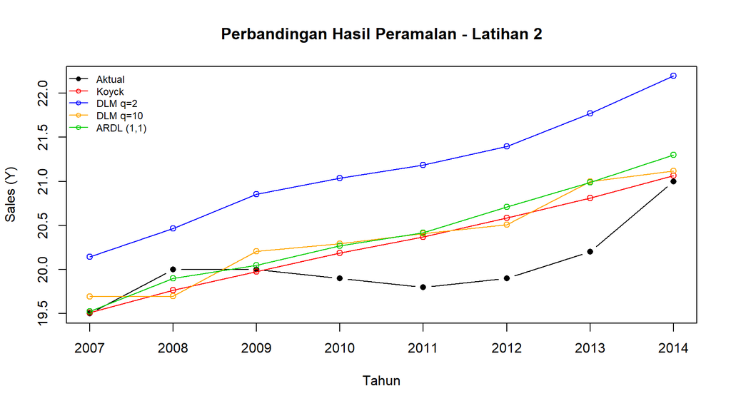

```r
rng2 <- range(c(test2$Yt, unlist(ramalan2)), na.rm = TRUE, finite = TRUE)

warna  <- c(Koyck = "red", DLM2 = "blue", DLMopt = "orange",
            ARDL11 = "green3", ARDLopt = "purple")
label2 <- c(Koyck = "Koyck", DLM2 = "DLM q=2",
            DLMopt = paste0("DLM q=", q.opt2),
            ARDL11 = "ARDL (1,1)",
            ARDLopt = paste0("ARDL optimum (p=", p_opt2, ", q=", q_opt2, ")"))

plot(test2$Year, test2$Yt, type = "b", pch = 16, col = "black", ylim = rng2,
     xlab = "Tahun", ylab = "Sales (Y)",
     main = "Perbandingan Hasil Peramalan - Latihan 2")

valid <- names(ramalan2)[sapply(ramalan2, function(z)
  length(z) == nrow(test2) && all(is.finite(z)))]

for (m in valid) {
  lines(test2$Year, ramalan2[[m]], col = warna[m])
  points(test2$Year, ramalan2[[m]], col = warna[m], pch = 1)
}

legend("topleft",
       legend = c("Aktual", label2[valid]),
       lty = 1, pch = c(16, rep(1, length(valid))),
       col = c("black", warna[valid]),
       cex = 0.75, bty = "n")
```